# HW10

# 連結資料

將訂單編號和腳踏車型號2個資料連結

再將第一個連接好的資料跟腳踏車商家資料連結

orderlines_tbl %>% left_join(bikes_tbl, by = c(“product.id”=“bike.id”)) %>% left_join(bikeshops_tbl, by = c(“customer.id” = “bikeshop.id”)) - 透過一個管道將orderlines_tbl丟到left_join中

```r
bike_orderlines_wrangled_tbl <- bikes_orderlines_joined_tbl %>%

  separate(description,
           into = c("category.1", "category.2", "frame.material"),
           sep = " - ",
           remove = TRUE) %>%

  separate(location,
           into = c("city", "state"),
           sep  = ", ",
           remove = FALSE) %>%

  mutate(total.price = price * quantity) %>%


  select(-1, -location) %>%
  select(-ends_with(".id")) %>%

  bind_cols(bikes_orderlines_joined_tbl %>% select(order.id)) %>%


  select(contains("date"), contains("id"), contains("order"),
         quantity, price, total.price,
         everything()) %>%


  rename(order_date = order.date) %>%
  set_names(names(.) %>% str_replace_all("\\.", "_"))

bike_orderlines_wrangled_tbl %>% glimpse()
```

```
## Observations: 15,644
## Variables: 13
## $ order_date     <dttm> 2011-01-07, 2011-01-07, 2011-01-10, 2011-01-10...
## $ order_id       <dbl> 1, 1, 2, 2, 3, 3, 3, 3, 3, 4, 5, 5, 5, 5, 6, 6,...
## $ order_line     <dbl> 1, 2, 1, 2, 1, 2, 3, 4, 5, 1, 1, 2, 3, 4, 1, 2,...
## $ quantity       <dbl> 1, 1, 1, 1, 1, 1, 1, 1, 1, 1, 1, 2, 1, 1, 1, 1,...
## $ price          <dbl> 6070, 5970, 2770, 5970, 10660, 3200, 12790, 533...
## $ total_price    <dbl> 6070, 5970, 2770, 5970, 10660, 3200, 12790, 533...
## $ model          <chr> "Jekyll Carbon 2", "Trigger Carbon 2", "Beast o...
## $ category_1     <chr> "Mountain", "Mountain", "Mountain", "Mountain",...
## $ category_2     <chr> "Over Mountain", "Over Mountain", "Trail", "Ove...
## $ frame_material <chr> "Carbon", "Carbon", "Aluminum", "Carbon", "Carb...
## $ bikeshop_name  <chr> "Ithaca Mountain Climbers", "Ithaca Mountain Cl...
## $ city           <chr> "Ithaca", "Ithaca", "Kansas City", "Kansas City...
## $ state          <chr> "NY", "NY", "KS", "KS", "KY", "KY", "KY", "KY",...
```

# 處理資料

將資料中description的部分分為category.1、category.2、frame.material 3個部分

將資料中location的部分分為city(城市)、state(州) 2個部分

將價格部份延長計算price * quantity(用mutate函數)

選擇要刪除的部分

將order_date = order.date重新命名

將有.的部分改用_取代重新命名

bike_orderlines_wrangled_tbl %>% glimpse() - 透過一個管道將bike_orderlines_wrangled_tbl丟到glimpse()中

```r
sales_by_year_tbl <- bike_orderlines_wrangled_tbl %>%
  select(order_date, total_price) %>%
  mutate(year = year(order_date)) %>%
  group_by(year) %>%
  summarize(sales = sum(total_price)) %>%
  ungroup() %>%
  mutate(sales_text = scales::dollar(sales))

sales_by_year_tbl
```

```
## # A tibble: 5 x 3
##    year    sales sales_text
##   <dbl>    <dbl> <chr>
## 1  2011 11292885 $11,292,885
## 2  2012 12163075 $12,163,075
## 3  2013 16480775 $16,480,775
## 4  2014 13924085 $13,924,085
## 5  2015 17171510 $17,171,510
```

# Sales by Year - Manipulate

select函數 - 選擇要的欄位

mutate函數 - 新增欄位

summarize函數 - 將數值整合(group_by(year)以年來計算)

mutate(sales_text = scales::dollar(sales)) - 將數字以會計風勢呈現

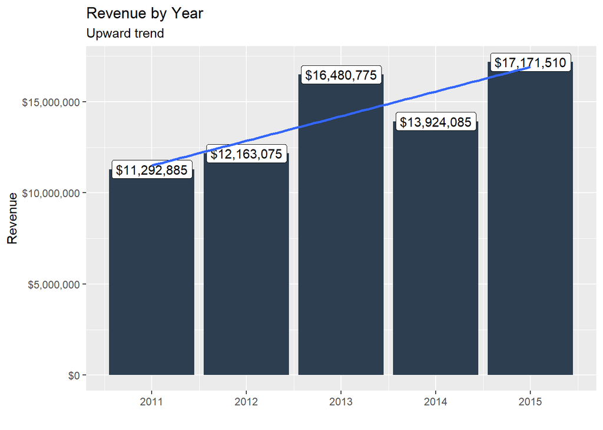

```r
sales_by_year_tbl %>%
  ggplot(aes(x = year, y = sales)) +
  geom_col(fill = "#2c3e50") +
  geom_label(aes(label = sales_text)) +
  geom_smooth(method = "lm", se = FALSE) +
  #theme_tq() +
  scale_y_continuous(labels = scales::dollar) +
  labs(
    title = "Revenue by Year",
    subtitle = "Upward trend",
    x = "",
    y = "Revenue"
  )
```

#Sales by Year - Visualize 用ggplot畫圖

geom_col - 劃出直方圖且可將文字標在圖表上

geom_label - 設置標籤

lm - 回歸線/se - 標準差

對X Y軸命名(x = “” - 已經是年的資料所以用“”表示、y = “Revenue” - 名稱為收入)

```r
sales_by_year_cat_2_tbl <- bike_orderlines_wrangled_tbl %>%
  select(order_date, total_price, category_2) %>%
  mutate(year = year(order_date)) %>%
  group_by(year, category_2) %>%
  summarise(sales = sum(total_price)) %>%
  ungroup() %>%
  mutate(sales_text = scales::dollar(sales))

sales_by_year_cat_2_tbl
```

```
## # A tibble: 45 x 4
##     year category_2           sales sales_text
##    <dbl> <chr>                <dbl> <chr>
##  1  2011 Cross Country Race 2917250 $2,917,250
##  2  2011 Cyclocross          378980 $378,980
##  3  2011 Elite Road         2493315 $2,493,315
##  4  2011 Endurance Road     1606230 $1,606,230
##  5  2011 Fat Bike            221600 $221,600
##  6  2011 Over Mountain      1328510 $1,328,510
##  7  2011 Sport               309290 $309,290
##  8  2011 Trail              1446560 $1,446,560
##  9  2011 Triathalon          591150 $591,150
## 10  2012 Cross Country Race 3360800 $3,360,800
## # ... with 35 more rows
```

# Sales by Year and Category 2 - Manipulate

將Y軸的名稱資訊改為會計的數字格式

mutate函數 - 新增欄位

mutate(sales_text = scales::dollar(sales)) - 將數字以會計風勢呈現

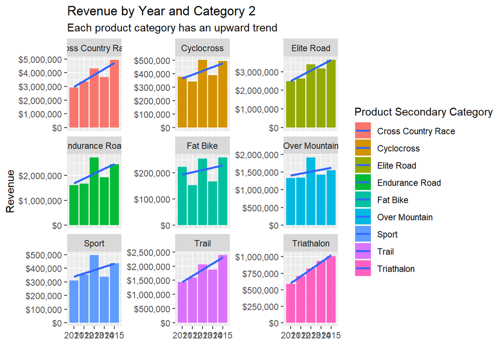

```r
P = sales_by_year_cat_2_tbl %>%
  ggplot(aes(x = year, y = sales, fill = category_2)) +
  geom_col() +
  geom_smooth(method = "lm", se = FALSE) +
  facet_wrap(~ category_2, ncol = 3, scales = "free_y") +
  #theme_tq() +
  #scale_fill_tq() +
  scale_y_continuous(labels = scales::dollar) +
  labs(
    title = "Revenue by Year and Category 2",
    subtitle = "Each product category has an upward trend",
    x = "",
    y = "Revenue",
    fill = "Product Secondary Category"
  )

P
```

#Sales by Year and Category 2 - Visualize 用ggplot畫圖

lm - 回歸線/se - 標準差

title = “Revenue by Year and Category 2” - 標題名稱為Revenue by Year and Category 2

副標題為Each product category has an upward trend

P - 將圖片輸出

# 存圖檔的方式

pdf(“ggplot.pdf”) print(p) dev.off()

ggsave(“myplot.pdf”) ggsave(“myplot.png”) ggsave(“myplot.pdf”, plot=p) (因為跑步出來所以文字呈現)

```r
fs::dir_create("data_wrangled_student")

bike_orderlines_wrangled_tbl %>%
  write_xlsx("data_wrangled_student/bike_orderlines.xlsx")

bike_orderlines_wrangled_tbl %>%
  write_csv("data_wrangled_student/bike_orderlines.csv")

bike_orderlines_wrangled_tbl %>%
  write_rds("data_wrangled_student/bike_orderlines.rds")
```

# Writing Files

Excel檔用write_xlsx函數

CSV檔用write_csv函數

RDS檔用write_rds函數

## 2. 下載台灣上市公司(不含TDR)之日收盤調整後股價、上市別、產業別，從2010/01/01-2018/12/31，並存為TXT檔。

```r
library(data.table)
```

# 下載並執行data.table

```r
d.price = read.table("C:/Users/Sarah/Desktop/FinDB_2019_Sales_Analysis/Price_2010-2018_day.txt")
d.price = d.price[,-2]
colnames(d.price) = c("id", "", "", "date","close")
head(d.price)
```

```
##         id                      date      close
## 1 證券代碼 上市別 TSE產業別   年月日 收盤價(元)
## 2     1101    TSE        01 20100104      19.70
## 3     1102    TSE        01 20100104      20.24
## 4     1103    TSE        01 20100104      13.91
## 5     1104    TSE        01 20100104      11.32
## 6     1108    TSE        01 20100104       6.82
```

```r
d.price
```

[output not shown]

[output cut: 19986 more lines]

用read.table函數讀txt資料

欄位名稱為“id”,“date”,“close”

head(d.price)顯示前幾筆資料

```r
dprice.reorder = dcast(d.price,date~id)
dprice.reorder
```

[output not shown]

[output cut: 8410 more lines]

```r
dim(dprice.reorder)
```

```
## [1] 2224  930
```

```r
head(dprice.reorder)
```

```
##       date  1101  1102  1103  1104 1108 1109  1110  1201  1203  1210 1213
## 1 20100104 19.70 20.24 13.91 11.32 6.82 8.45 10.55 39.77 17.22 15.16 9.23
## 2 20100105 20.39 20.68 13.83 11.13 6.77 8.49 10.64 39.81 17.19 15.18 8.94
## 3 20100106 20.82 20.83 13.60 11.22 6.76 8.57 10.78 39.81 17.29 15.44 9.09
## 4 20100107 20.42 20.59 13.38 10.95 6.88 8.61 10.74 39.72 17.09 15.18 8.89
## 5 20100108 20.33 20.71 13.57 11.01 6.95 8.61 10.83 39.35 17.16 15.31 8.92
## 6 20100111 19.96 20.56 13.91 11.35 7.01 8.65 11.55 38.61 17.32 15.79 9.06
##   1215  1216  1217  1218  1219 1220  1225  1227 1229 1231  1232  1233
## 1 9.07 20.01 12.72 10.81  9.58 7.24 12.63 12.70 7.67 7.24 22.36 23.64
## 2 9.16 19.72 12.67 11.23  9.55 7.09 12.63 12.60 7.69 7.19 22.33 24.03
## 3 9.34 20.03 12.77 11.27  9.62 7.12 12.83 12.81 7.79 7.21 22.53 24.19
## 4 9.22 19.54 12.53 11.35  9.55 6.99 12.86 12.58 7.64 7.19 22.53 24.36
## 5 9.31 19.54 12.58 11.31  9.69 7.06 12.83 12.52 7.81 7.21 22.62 23.96
## 6 9.92 19.62 12.82 11.48 10.34 7.38 13.71 12.45 7.96 7.40 22.91 23.90
##    1234  1235  1236 1256 1262  1301  1303  1304 1305  1307  1308  1309
```

[output cut: 510 more lines]

head(dprice.reorder)顯示前幾筆資料

```r
write_rds(dprice.reorder,"d_price.rds")
```

# 將檔案輸出儲存成rds格式